# Heart Disease Prediction

## Importing Libraries

```python
#Let's start with importing necessary libraries

import pandas as pd
import numpy as np
import seaborn as sns
import matplotlib.pyplot as plt
import warnings

warnings.filterwarnings("ignore")

from sklearn.model_selection import train_test_split
from sklearn.preprocessing import StandardScaler
from sklearn.linear_model  import LogisticRegression
from sklearn.metrics import accuracy_score, confusion_matrix, roc_curve, roc_auc_score
```

```python
#Matplotlib is a Python library that allows you to create various types of plots and visualizations with your data
#it is dividing data into 2 part first is training and second is test
```

### Load Dataset

```python
#loding the excel data to a pandas dataframe
df=pd.read_excel(r"C:\Users\SANJEEV\Downloads\Ch3.ClevelandData.xlsx")
```

```python
## print the top5 records

df.head()
```

|  | age | sex | cp | trestbps | chol | fbs | restecg | thalach | exang | oldpeak | slope | ca | hal | HeartDisease |
| --- | --- | --- | --- | --- | --- | --- | --- | --- | --- | --- | --- | --- | --- | --- |
| 0 | 63 | 1 | 1 | 145 | 233 | 1 | 2 | 150 | 0 | 2.3 | 3 | 0 | 6 | 0 |
| 1 | 67 | 1 | 4 | 160 | 286 | 0 | 2 | 108 | 1 | 1.5 | 2 | 3 | 3 | 1 |
| 2 | 67 | 1 | 4 | 120 | 229 | 0 | 2 | 129 | 1 | 2.6 | 2 | 2 | 7 | 1 |
| 3 | 37 | 1 | 3 | 130 | 250 | 0 | 0 | 187 | 0 | 3.5 | 3 | 0 | 3 | 0 |
| 4 | 41 | 0 | 2 | 130 | 204 | 0 | 2 | 172 | 0 | 1.4 | 1 | 0 | 3 | 0 |

```python
## print the last 5 records

df.tail()
```

|  | age | sex | cp | trestbps | chol | fbs | restecg | thalach | exang | oldpeak | slope | ca | hal | HeartDisease |
| --- | --- | --- | --- | --- | --- | --- | --- | --- | --- | --- | --- | --- | --- | --- |
| 298 | 45 | 1 | 1 | 110 | 264 | 0 | 0 | 132 | 0 | 1.2 | 2 | 0 | 7 | 1 |
| 299 | 68 | 1 | 4 | 144 | 193 | 1 | 0 | 141 | 0 | 3.4 | 2 | 2 | 7 | 1 |
| 300 | 57 | 1 | 4 | 130 | 131 | 0 | 0 | 115 | 1 | 1.2 | 2 | 1 | 7 | 1 |
| 301 | 57 | 0 | 2 | 130 | 236 | 0 | 2 | 174 | 0 | 0.0 | 2 | 1 | 3 | 1 |
| 302 | 38 | 1 | 3 | 138 | 175 | 0 | 0 | 173 | 0 | 0.0 | 1 | ? | 3 | 0 |

```python
## Displays information about the DataFrame, including data types, memory usage, and presence of missing values.
df.info()
```

```
<class 'pandas.core.frame.DataFrame'>
RangeIndex: 303 entries, 0 to 302
Data columns (total 14 columns):
 #   Column        Non-Null Count  Dtype
---  ------        --------------  -----
 0   age           303 non-null    int64
 1   sex           303 non-null    int64
 2   cp            303 non-null    int64
 3   trestbps      303 non-null    int64
 4   chol          303 non-null    int64
 5   fbs           303 non-null    int64
 6   restecg       303 non-null    int64
 7   thalach       303 non-null    int64
 8   exang         303 non-null    int64
 9   oldpeak       303 non-null    float64
 10  slope         303 non-null    int64
 11  ca            303 non-null    object
 12  hal           303 non-null    object
 13  HeartDisease  303 non-null    int64
dtypes: float64(1), int64(11), object(2)
memory usage: 33.3+ KB
```

Number of Entries: The dataset consists of 303 entries, ranging from index 0 to 302.

Columns: There are 14 columns in the dataset corresponding to various attributes of the patients and results of tests.

Missing Values: There don't appear to be any missing values in the dataset as each column has 303 non-null entries.

```python
## print shape of dataset with rows and columns

df.shape
```

```
(303, 14)
```

This data contains 303 rows and 14 columns

```python
## finding the count of mission value  from  different columns
df.isna().sum()
```

```
age             0
sex             0
cp              0
trestbps        0
chol            0
fbs             0
restecg         0
thalach         0
exang           0
oldpeak         0
slope           0
ca              0
hal             0
HeartDisease    0
dtype: int64
```

As we can see from the above info that the our dataset has 14 columns and each columns has 303 values. There is no Null values in the dataset.

```python
## Check statistics of data set
df.describe()
```

|  | age | sex | cp | trestbps | chol | fbs | restecg | thalach | exang | oldpeak | slope | HeartDisease |
| --- | --- | --- | --- | --- | --- | --- | --- | --- | --- | --- | --- | --- |
| count | 303.000000 | 303.000000 | 303.000000 | 303.000000 | 303.000000 | 303.000000 | 303.000000 | 303.000000 | 303.000000 | 303.000000 | 303.000000 | 303.000000 |
| mean | 54.438944 | 0.679868 | 3.158416 | 131.689769 | 246.693069 | 0.148515 | 0.990099 | 149.607261 | 0.326733 | 1.039604 | 1.600660 | 0.458746 |
| std | 9.038662 | 0.467299 | 0.960126 | 17.599748 | 51.776918 | 0.356198 | 0.994971 | 22.875003 | 0.469794 | 1.161075 | 0.616226 | 0.499120 |
| min | 29.000000 | 0.000000 | 1.000000 | 94.000000 | 126.000000 | 0.000000 | 0.000000 | 71.000000 | 0.000000 | 0.000000 | 1.000000 | 0.000000 |
| 25% | 48.000000 | 0.000000 | 3.000000 | 120.000000 | 211.000000 | 0.000000 | 0.000000 | 133.500000 | 0.000000 | 0.000000 | 1.000000 | 0.000000 |
| 50% | 56.000000 | 1.000000 | 3.000000 | 130.000000 | 241.000000 | 0.000000 | 1.000000 | 153.000000 | 0.000000 | 0.800000 | 2.000000 | 0.000000 |
| 75% | 61.000000 | 1.000000 | 4.000000 | 140.000000 | 275.000000 | 0.000000 | 2.000000 | 166.000000 | 1.000000 | 1.600000 | 2.000000 | 1.000000 |
| max | 77.000000 | 1.000000 | 4.000000 | 200.000000 | 564.000000 | 1.000000 | 2.000000 | 202.000000 | 1.000000 | 6.200000 | 3.000000 | 1.000000 |

# Numerical Features:

age: The average age of the patients is approximately 54.4 years, with the youngest being 29 and the oldest 77 years.

trestbps: The average resting blood pressure is about 131.69 mm Hg, ranging from 94 to 200 mm Hg.

chol: The average cholesterol level is approximately 246.70 mg/dl, with a minimum of 126 and a maximum of 564 mg/dl.

thalach: The average maximum heart rate achieved is around 149.60 , with a range from 71 to 202.

oldpeak: The average ST depression induced by exercise relative to rest is about 1.04, with values ranging from 0 to 6.2.

```python
# checking duplicate value
data_dup=df.duplicated().any()
```

```python
data_dup
```

```
False
```

```python
#check for the data characters mistakes
for i in df.columns:
    print(i, df[df[i]=='?'].shape[0])
```

```
age 0
sex 0
cp 0
trestbps 0
chol 0
fbs 0
restecg 0
thalach 0
exang 0
oldpeak 0
slope 0
ca 4
hal 2
HeartDisease 0
```

```python
## check for the data characters mistakes
df['ca'] = df['ca'].replace('?', np.nan)
df['hal'] = df['hal'].replace('?', np.nan)
```

```python
## finding the count of missing value from different columns
df.isna().sum()
```

```
age             0
sex             0
cp              0
trestbps        0
chol            0
fbs             0
restecg         0
thalach         0
exang           0
oldpeak         0
slope           0
ca              4
hal             2
HeartDisease    0
dtype: int64
```

```python
## Replace the Nan with Mode.
df['ca'].fillna(df['ca'].mean(),inplace=True)
df['hal'].fillna(df['hal'].mean(),inplace=True)
```

```python
# to check missing values
df.isna().sum()
```

```
age             0
sex             0
cp              0
trestbps        0
chol            0
fbs             0
restecg         0
thalach         0
exang           0
oldpeak         0
slope           0
ca              0
hal             0
HeartDisease    0
dtype: int64
```

```python
# displaying columns names
df.columns
```

```
Index(['age', 'sex', 'cp', 'trestbps', 'chol', 'fbs', 'restecg', 'thalach',
       'exang', 'oldpeak', 'slope', 'ca', 'hal', 'HeartDisease'],
      dtype='object')
```

```python
# to know the type of variable
df.nunique()
```

```
age              41
sex               2
cp                4
trestbps         50
chol            152
fbs               2
restecg           3
thalach          91
exang             2
oldpeak          40
slope             3
ca                5
hal               4
HeartDisease      2
dtype: int64
```

```python
# for unique values
df['hal'].unique()
```

```
array([6.        , 3.        , 7.        , 4.73421927])
```

```python
#count() method to count how many times a specific number appears in the list
df['HeartDisease'].value_counts()
```

```
0    164
1    139
Name: HeartDisease, dtype: int64
```

1 = HeartDisease , 0 = No HeartDisease

```python
# finding categorical and  continuous  columns
cate_val=[]
cont_val=[]

for columns in df.columns:
    if df[columns].nunique() <=10:
        cate_val.append(columns)
    else:
        cont_val.append(columns)
```

```python
# categorical columns
cate_val
```

```
['sex', 'cp', 'fbs', 'restecg', 'exang', 'slope', 'ca', 'hal', 'HeartDisease']
```

```python
# continuous  columns
cont_val
```

```
['age', 'trestbps', 'chol', 'thalach', 'oldpeak']
```

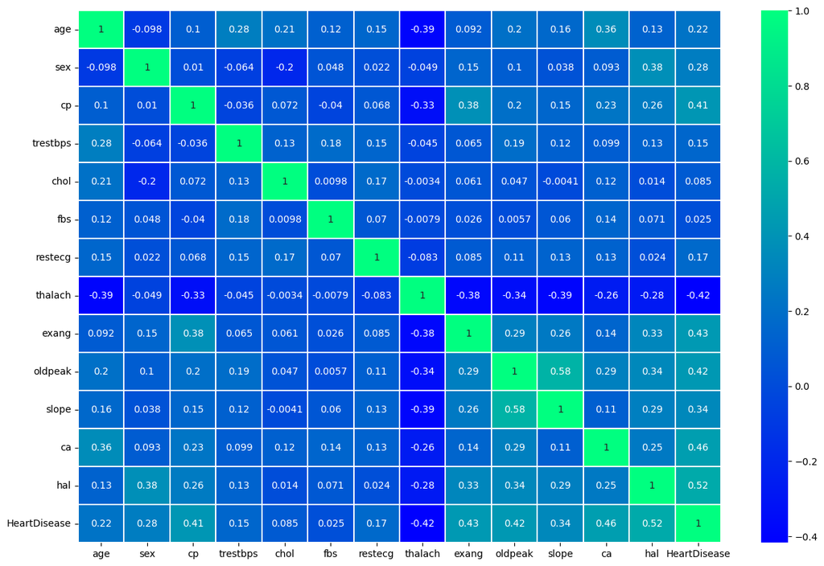

```python
plt.figure(figsize=(15,10))
sns.heatmap(df.corr(),linewidth=0.1,annot=True,cmap="winter")
plt.show()
plt.savefig('correlationfigure')
```

## Observations from heatmap:

fbs and chol are the least correlated with the target variable.

```python
df['HeartDisease'] = df.HeartDisease.replace({1: "Disease", 0: "No_disease"})
df['sex'] = df.sex.replace({1: "Male", 0: "Female"})
df['cp'] = df.cp.replace({1: "typical_angina",
                          2: "atypical_angina",
                          3:"non-anginal pain",
                          4: "asymtomatic"})
df['exang'] = df.exang.replace({1: "Yes", 0: "No"})
df['fbs'] = df.fbs.replace({1: "True", 0: "False"})
df['slope'] = df.slope.replace({1: "upsloping", 2: "flat",3:"downsloping"})
df['hal'] = df.hal.replace({6: "fixed_defect", 7: "reversable_defect", 3:"normal"})
```

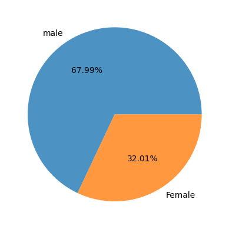

```python
plt.pie(df['sex'].value_counts(),labels=['male', 'Female'], autopct='%.2f%%', wedgeprops=dict(alpha=0.8))
plt.show()
```

In the heart disease UCI dataset only 32.01% are female and rest are male. we have find that either male or female which have likely to heart disease.

```python
df['cp'].value_counts()
```

```
asymtomatic         144
non-anginal pain     86
atypical_angina      50
typical_angina       23
Name: cp, dtype: int64
```

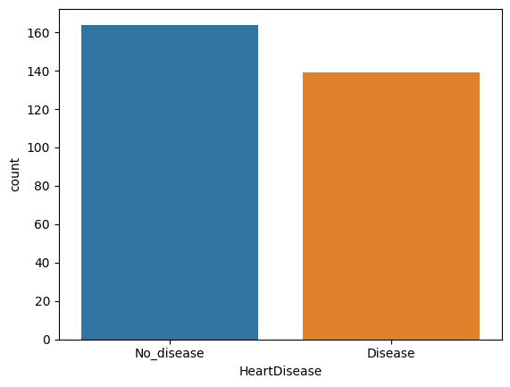

```python
sns.countplot(x='HeartDisease', data=df)
```

There are less diseased than healthy patients.

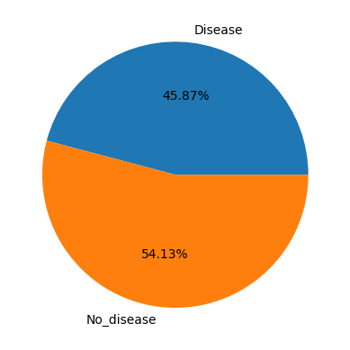

```python
df.groupby('HeartDisease').size().plot(kind='pie', autopct='%.2f%%')

plt.show()
```

The table above shows the prevalence of heart disease in the dataset, with approximately 54.13% of individuals not having heart disease and about 45.87% having heart disease. This indicates that nearly half of the individuals in this dataset have heart disease, which is a significant proportion and underscores the importance of understanding factors like cholesterol levels in relation to heart health.

# Investigate the relationship between age, sex, blood pressure, and heart disease

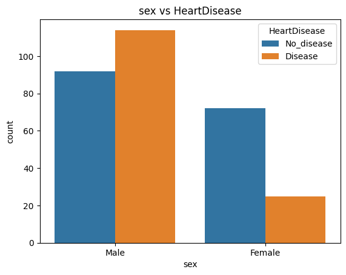

```python
sns.countplot(x='sex',hue="HeartDisease",data=df).set(title="sex vs HeartDisease")
plt.show()
```

from this countplot we can see that there are more male in this study so no disease and disease males are more than female

```python
# replace the values in the 'cp' column with 0,1,2,3 for 1,2,3,4
df['cp'] = df['cp'].replace({'typical_angina':0 , 'atypical_angina':1, 'non-anginal pain':2, 'asymtomatic':3})
```

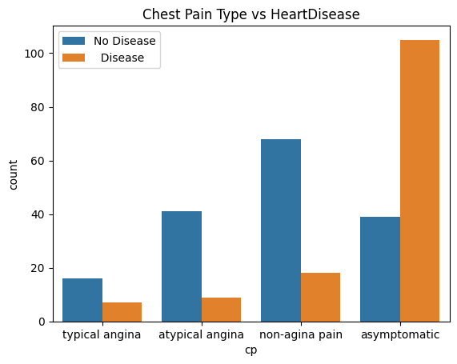

```python
# check chest pain type which chest pain is common in people there are 4 type of chest pain
sns.countplot(x="cp",hue="HeartDisease",data=df).set(title="Chest Pain Type vs HeartDisease")
plt.xticks([0,1,2,3],['typical angina','atypical angina','non-agina pain','asymptomatic'])
plt.legend(labels=['No Disease','  Disease'])
plt.show()
```

Conclusions

Most of our samples have a asymptomatic chest pain type.

Patients who have asymtomatic angina are more likely to have heart disease.

Most of the healthy people have a non-anginal chest pain type.

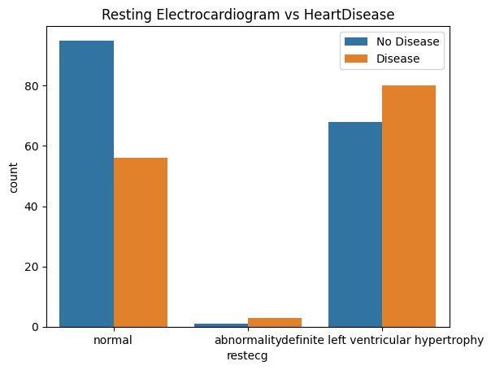

```python
sns.countplot(x="restecg",hue="HeartDisease",data=df).set(title="Resting Electrocardiogram vs HeartDisease")
plt.xticks([0,1,2],['normal','abnormality','definite left ventricular hypertrophy'])
plt.legend(labels=['No Disease','Disease'])
plt.show()
```

Conclusions

People who have left ventricular hypertrophy are more likely to have less heart disease chance than Patients who have Probable abnormality definite

[figure not shown]

```python
sns.countplot(x="fbs",hue="HeartDisease",data=df).set(title="Fasting Blood Sugar vs HeartDisease")
plt.xticks([0,1],['fast blood sugar<120 mg/dl','fast blood sugar>120 mg/dl'])
plt.legend(labels=['No Disease','Disease'])
plt.show()
```

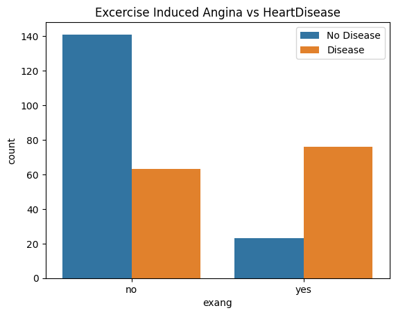

```python
sns.countplot(x="exang",hue="HeartDisease",data=df).set(title="Excercise Induced Angina vs HeartDisease")
plt.xticks([0,1],['no','yes'])
plt.legend(labels=['No Disease','Disease'])
plt.show()
```

Conclusions

People have Exercise induced angina are more likely to have heart disease.

```python
df['slope'] = df['slope'].replace({'upsloping':0 , 'flat':1, 'downsloping':2,})
```

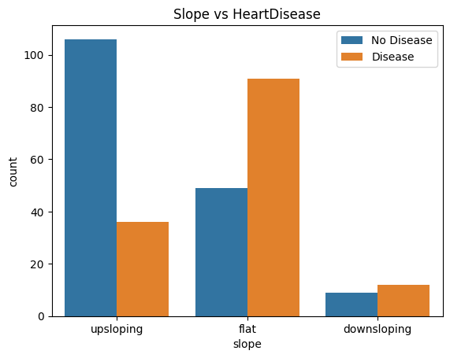

```python
sns.countplot(x="slope",hue="HeartDisease",data=df).set(title="Slope vs HeartDisease")
plt.xticks([0,1,2],['upsloping','flat','downsloping'])
plt.legend(labels=['No Disease','Disease'])
plt.show()
```

Most of patient have upsloping or Flat slope.

Patient who have flat slope are more likely to have heart disease.

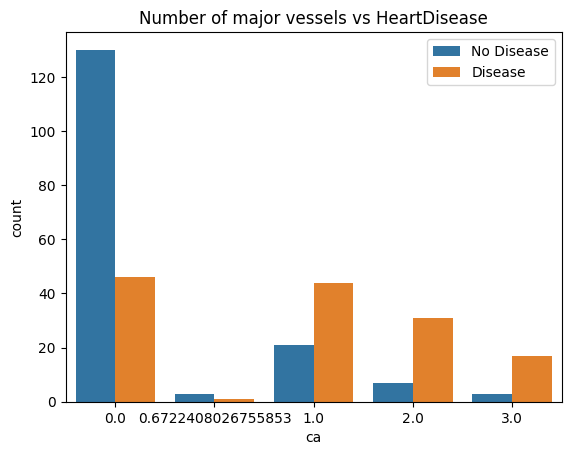

```python
sns.countplot(x="ca",hue="HeartDisease",data=df).set(title="Number of major vessels vs HeartDisease")
plt.legend(labels=['No Disease','Disease'])
plt.show()
```

Conclusions

Most of people have zero number of number of major vessels.

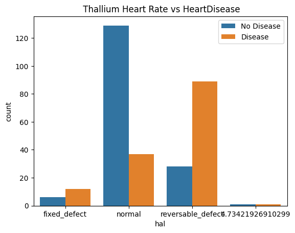

```python
sns.countplot(x="hal",hue="HeartDisease",data=df).set(title=' Thallium Heart Rate vs HeartDisease')
plt.legend(labels=['No Disease','Disease'])
plt.show()
```

Conclusions

Patient who have thal value (reversable_defect) more likely to have heart disease.

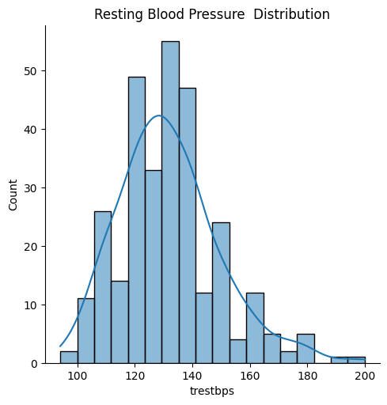

```python
sns.displot(df['trestbps'],kde='True')
plt.title('Resting Blood Pressure  Distribution' )
plt.show()
```

from this histogrsm we can see the blood pressure in the people is between 120 to 140

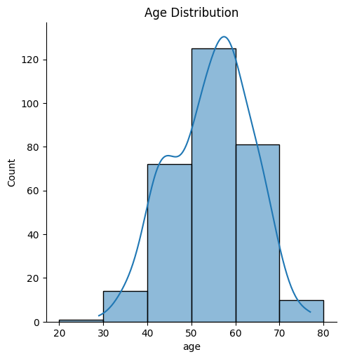

```python
sns.displot(df['age'],bins=[20,30,40,50,60,70,80],kde='True')
plt.title('Age Distribution')
plt.show()
```

from this histogram we can see that most of the patients are in the age between 50 to 60

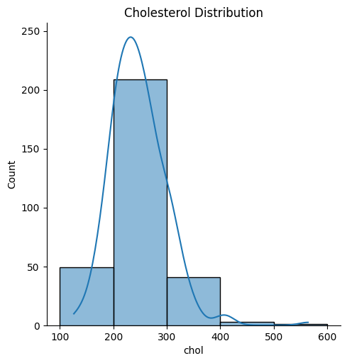

```python
sns.displot(df['chol'],bins=(100,200,300,400,500,600),kde='True')
plt.title('Cholesterol Distribution')
plt.show()
```

Conclusions

Cholestoral is positive skewed, meaning that few patients have high cholestoral.

Most of patients have high cholestoral level, compared to patients with low cholestoral level.

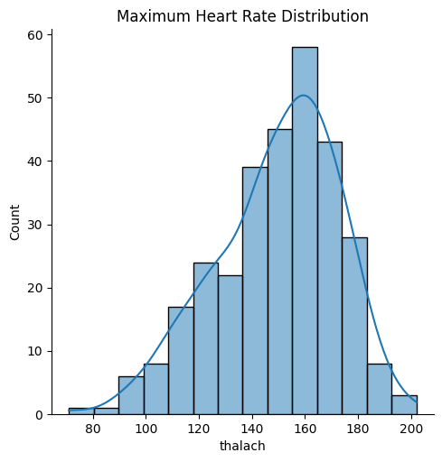

```python
sns.displot(df['thalach'],kde='True')
plt.title('Maximum Heart Rate Distribution')
plt.show()
```

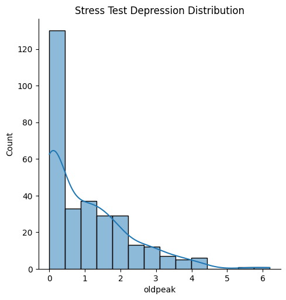

```python
sns.displot(df['oldpeak'],kde='True')
plt.title('Stress Test Depression Distribution')
plt.show()
```

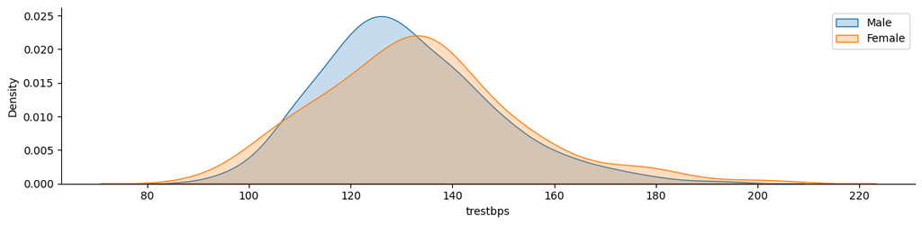

```python
g=sns.FacetGrid(df,hue="sex",aspect=4)
g.map(sns.kdeplot,'trestbps',shade=True)
plt.legend(labels=['Male','Female'])
```

```python
continous_features = ['age','trestbps','chol','thalach','oldpeak']
def outliers(df_out, drop = False):
    for each_feature in df_out.columns:
        feature_data = df_out[each_feature]
        Q1 = np.percentile(feature_data, 25.) # 25th percentile of the data of the given feature
        Q3 = np.percentile(feature_data, 75.) # 75th percentile of the data of the given feature
        IQR = Q3-Q1 #Interquartile Range
        outlier_step = IQR * 1.5 #That's we were talking about above
        outliers = feature_data[~((feature_data >= Q1 - outlier_step) & (feature_data <= Q3 + outlier_step))].index.tolist()
        if not drop:
            print('For the feature {}, No of Outliers is {}'.format(each_feature, len(outliers)))
        if drop:
            df.drop(outliers, inplace = True, errors = 'ignore')
            print('Outliers from {} feature removed'.format(each_feature))

outliers(df[continous_features])
```

```
For the feature age, No of Outliers is 0
For the feature trestbps, No of Outliers is 9
For the feature chol, No of Outliers is 5
For the feature thalach, No of Outliers is 1
For the feature oldpeak, No of Outliers is 5
```

```python
outliers(df[continous_features],drop='True')
```

```
Outliers from age feature removed
Outliers from trestbps feature removed
Outliers from chol feature removed
Outliers from thalach feature removed
Outliers from oldpeak feature removed
```

```python
df.shape
```

```
(284, 14)
```

# convert variable to numeric

```python
df['HeartDisease'] = df.HeartDisease.replace({ "Disease":1,  "No_disease":0})
df['sex'] = df.sex.replace({ "Male":1,  "Female":0})

df['exang'] = df.exang.replace({ "Yes":1, "No":0})
df['fbs'] = df.fbs.replace({"True":1,  "False":0})
df['slope'] = df.slope.replace({'upsloping':0 ,'flat':1,'downsloping':2})
df['hal']=df.hal.replace({"fixed_defect":6, "reversable_defect":7, "normal":3})
```

```python
df.head()
```

|  | age | sex | cp | trestbps | chol | fbs | restecg | thalach | exang | oldpeak | slope | ca | hal | HeartDisease |
| --- | --- | --- | --- | --- | --- | --- | --- | --- | --- | --- | --- | --- | --- | --- |
| 0 | 63 | 1 | 0 | 145 | 233 | 1 | 2 | 150 | 0 | 2.3 | 2 | 0.0 | 6.0 | 0 |
| 1 | 67 | 1 | 3 | 160 | 286 | 0 | 2 | 108 | 1 | 1.5 | 1 | 3.0 | 3.0 | 1 |
| 2 | 67 | 1 | 3 | 120 | 229 | 0 | 2 | 129 | 1 | 2.6 | 1 | 2.0 | 7.0 | 1 |
| 3 | 37 | 1 | 2 | 130 | 250 | 0 | 0 | 187 | 0 | 3.5 | 2 | 0.0 | 3.0 | 0 |
| 4 | 41 | 0 | 1 | 130 | 204 | 0 | 2 | 172 | 0 | 1.4 | 0 | 0.0 | 3.0 | 0 |

# Splitinng Data

```python
## Define the features (X) and the output labels (y)

X = df.drop(columns = ['HeartDisease'])
y = df['HeartDisease']
```

```python
scalar = StandardScaler()
X_scaled = scalar.fit_transform(X)
```

```python
# Splitting data into train and test sets
X_train,X_test,y_train,y_test = train_test_split(X_scaled,y, test_size= 0.25, random_state = 10)
```

# logistic regression

```python
from sklearn.linear_model import LogisticRegression
logreg = LogisticRegression(random_state=4)
logreg.fit(X_train, y_train)
logpredict = logreg.predict(X_test)
```

```python
# print the accuracy for train and test data
print(logreg.score(X_train,y_train))
print(logreg.score(X_test,y_test))
```

```
0.8450704225352113
0.8309859154929577
```

```python
#printing confusion matrix and classification report
from sklearn.metrics import accuracy_score, classification_report, confusion_matrix
print(confusion_matrix(y_test, logpredict))
print(classification_report(y_test, logpredict))
print(accuracy_score(y_test, logpredict))
```

```
[[37  3]
 [ 9 22]]
              precision    recall  f1-score   support

           0       0.80      0.93      0.86        40
           1       0.88      0.71      0.79        31

    accuracy                           0.83        71
   macro avg       0.84      0.82      0.82        71
weighted avg       0.84      0.83      0.83        71

0.8309859154929577
```

Let's see how well our model performs on the test data set.

```python
auc = roc_auc_score(y_test, logpredict)
auc
```

```
0.8173387096774194
```

```python
fpr, tpr, thresholds = roc_curve(y_test,logpredict )
```

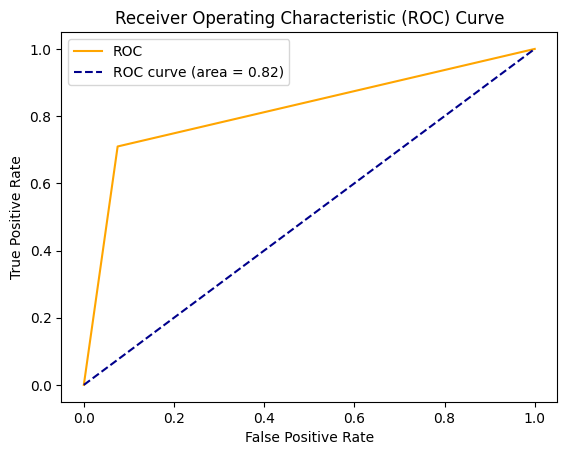

```python
plt.plot(fpr, tpr, color='orange', label='ROC')
plt.plot([0, 1], [0, 1], color='darkblue', linestyle='--',label='ROC curve (area = %0.2f)' % auc)
plt.xlabel('False Positive Rate')
plt.ylabel('True Positive Rate')
plt.title('Receiver Operating Characteristic (ROC) Curve')
plt.legend()
plt.show()
```

# Decision Tree

```python
from sklearn.tree import DecisionTreeClassifier
dtree = DecisionTreeClassifier(random_state=1)
dtree.fit(X_train,y_train)
pred_dtree = dtree.predict(X_test)
```

```python
# printing the accuracy for train and test data
print(dtree.score(X_train,y_train))
print(dtree.score(X_test,y_test))
```

```
1.0
0.704225352112676
```

```python
# printing confusion matrix and classification report
print(confusion_matrix(y_test, pred_dtree))
print(classification_report(y_test,pred_dtree))
print(accuracy_score(y_test, pred_dtree))
```

```
[[29 11]
 [10 21]]
              precision    recall  f1-score   support

           0       0.74      0.72      0.73        40
           1       0.66      0.68      0.67        31

    accuracy                           0.70        71
   macro avg       0.70      0.70      0.70        71
weighted avg       0.71      0.70      0.70        71

0.704225352112676
```

```python
auc = roc_auc_score(y_test, pred_dtree)
auc
```

```
0.7012096774193548
```

```python
fpr, tpr, thresholds = roc_curve(y_test,pred_dtree )
```

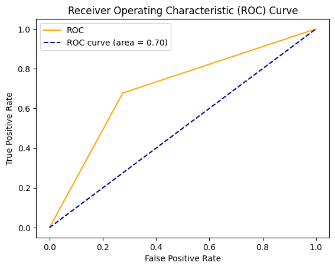

```python
plt.plot(fpr, tpr, color='orange', label='ROC')
plt.plot([0, 1], [0, 1], color='darkblue', linestyle='--',label='ROC curve (area = %0.2f)' % auc)
plt.xlabel('False Positive Rate')
plt.ylabel('True Positive Rate')
plt.title('Receiver Operating Characteristic (ROC) Curve')
plt.legend()
plt.show()
```

# Random Forest Classifier

```python
from sklearn.ensemble import RandomForestClassifier
rfc = RandomForestClassifier()
rfc.fit(X_train, y_train)
pred_rfc = rfc.predict(X_test)
```

```python
# printing the accuracy for train and test data
print(rfc.score(X_train,y_train))
print(rfc.score(X_test,y_test))
```

```
1.0
0.7605633802816901
```

```python
#printing confusion matrix and classification report
print(confusion_matrix(y_test, pred_rfc))
print(classification_report(y_test, pred_rfc))
print(accuracy_score(y_test, pred_rfc))
```

```
[[34  6]
 [11 20]]
              precision    recall  f1-score   support

           0       0.76      0.85      0.80        40
           1       0.77      0.65      0.70        31

    accuracy                           0.76        71
   macro avg       0.76      0.75      0.75        71
weighted avg       0.76      0.76      0.76        71

0.7605633802816901
```

```python
auc = roc_auc_score(y_test, pred_rfc)
auc
```

```
0.7475806451612902
```

```python
fpr, tpr, thresholds = roc_curve(y_test,pred_rfc )
```

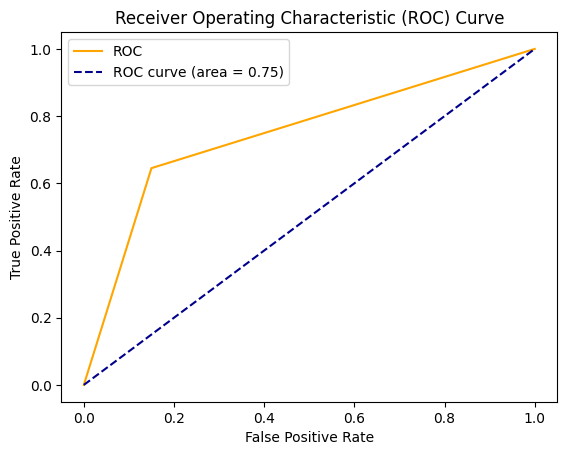

```python
plt.plot(fpr, tpr, color='orange', label='ROC')
plt.plot([0, 1], [0, 1], color='darkblue', linestyle='--',label='ROC curve (area = %0.2f)' % auc)
plt.xlabel('False Positive Rate')
plt.ylabel('True Positive Rate')
plt.title('Receiver Operating Characteristic (ROC) Curve')
plt.legend()
plt.show()
```

# SVM Classifier

```python
from sklearn.svm import SVC
svc = SVC(gamma = 0.01, C = 100)
svc.fit(X_train, y_train)
pred_svc = svc.predict(X_test)
```

```python
# printing the accuracy for train and test data
print(svc.score(X_train,y_train))
print(svc.score(X_test,y_test))
```

```
0.9389671361502347
0.7323943661971831
```

```python
# printing confusion matrix and classification report
print(confusion_matrix(y_test, pred_svc))
print(classification_report(y_test, pred_svc))
print(accuracy_score(y_test, pred_svc))
```

```
[[30 10]
 [ 9 22]]
              precision    recall  f1-score   support

           0       0.77      0.75      0.76        40
           1       0.69      0.71      0.70        31

    accuracy                           0.73        71
   macro avg       0.73      0.73      0.73        71
weighted avg       0.73      0.73      0.73        71

0.7323943661971831
```

```python
auc = roc_auc_score(y_test, pred_svc)
auc
```

```
0.7298387096774194
```

```python
fpr, tpr, thresholds = roc_curve(y_test,pred_svc )
```

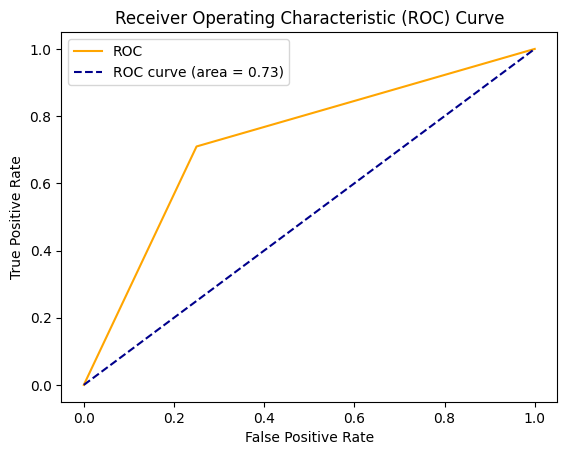

```python
plt.plot(fpr, tpr, color='orange', label='ROC')
plt.plot([0, 1], [0, 1], color='darkblue', linestyle='--',label='ROC curve (area = %0.2f)' % auc)
plt.xlabel('False Positive Rate')
plt.ylabel('True Positive Rate')
plt.title('Receiver Operating Characteristic (ROC) Curve')
plt.legend()
plt.show()
```

# Gradient Boosting Classifier

```python
from sklearn.ensemble import GradientBoostingClassifier
gbc = GradientBoostingClassifier()
gbc.fit(X_train, y_train)
gbc_pred = gbc.predict(X_test)
```

```python
# printing the accuracy for train and test data
print(gbc.score(X_train,y_train))
print(gbc.score(X_test,y_test))
```

```
1.0
0.7464788732394366
```

```python
# printing confusion matrix and classification report
print(confusion_matrix(y_test, gbc_pred))
print(classification_report(y_test, gbc_pred))
print(accuracy_score(y_test, gbc_pred))
```

```
[[32  8]
 [10 21]]
              precision    recall  f1-score   support

           0       0.76      0.80      0.78        40
           1       0.72      0.68      0.70        31

    accuracy                           0.75        71
   macro avg       0.74      0.74      0.74        71
weighted avg       0.75      0.75      0.75        71

0.7464788732394366
```

```python
auc = roc_auc_score(y_test, gbc_pred)
auc
```

```
0.7387096774193548
```

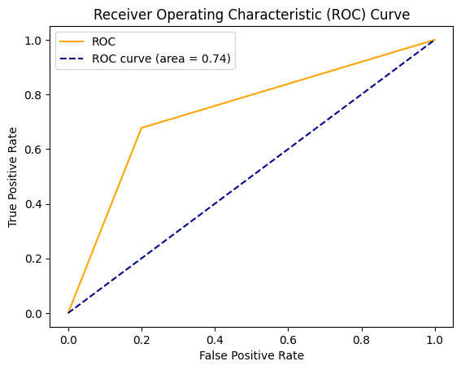

```python
fpr, tpr, thresholds = roc_curve(y_test,gbc_pred )
plt.plot(fpr, tpr, color='orange', label='ROC')
plt.plot([0, 1], [0, 1], color='darkblue', linestyle='--',label='ROC curve (area = %0.2f)' % auc)
plt.xlabel('False Positive Rate')
plt.ylabel('True Positive Rate')
plt.title('Receiver Operating Characteristic (ROC) Curve')
plt.legend()
plt.show()
```

```python
from sklearn.model_selection import RepeatedStratifiedKFold
from sklearn.model_selection import GridSearchCV

# To store models created
best_models = {}


def print_best_parameters(hyperparameters, best_parameters):
    value = "Best parameters: "
    for key in hyperparameters:
        value += str(key) + ": " + str(best_parameters[key]) + ", "
    if hyperparameters:
        print(value[:-2])

def get_best_model(estimator, hyperparameters, fit_params={}):
    cv = RepeatedStratifiedKFold(n_splits=10, n_repeats=3, random_state=1)
    grid_search = GridSearchCV(estimator=estimator, param_grid=hyperparameters, n_jobs=-1, cv=cv, scoring="accuracy")
    best_model = grid_search.fit(X_train, y_train, **fit_params)
    best_parameters = best_model.best_estimator_.get_params()
    print_best_parameters(hyperparameters, best_parameters)
    return best_model

def evaluate_model(model, name):
    print("Accuracy score:", accuracy_score(y_train, model.predict(X_train)))
    best_models[name] = model
```

```python
## Logistic Regression

hyperparameters = {
    'solver'  : ['newton-cg', 'lbfgs', 'liblinear'],
    'penalty' : ['l2'],
    'C'       : [0, 8, 50]
}
estimator = LogisticRegression(random_state=1)
best_model_logistic = get_best_model(estimator, hyperparameters)

LR_accuracy = evaluate_model(best_model_logistic.best_estimator_, 'logistic')
```

```
Best parameters: solver: newton-cg, penalty: l2, C: 50
Accuracy score: 0.8356807511737089
```

```python
## SVM Classifier

hyperparameters = {
    'C'      : [0.1, 1, 10, 100],
    'gamma'  : [0.0001, 0.001, 0.01, 0.1, 1],
    'kernel' : ['linear','rbf','poly'],
    'degree' :[2,3,4]
}
estimator = SVC(random_state=1)
best_model_svc = get_best_model(estimator, hyperparameters)

SVM_accuracy = evaluate_model(best_model_svc.best_estimator_, 'svc')
```

```
Best parameters: C: 1, gamma: 0.1, kernel: poly, degree: 3
Accuracy score: 0.9624413145539906
```

```python
## Decision Tree

hyperparameters = {
    'criterion'         : ['gini', 'entropy'],
    'splitter'          : ['best', 'random'],
    'max_depth'         : [None, 1, 2, 3, 4, 5],
    'min_samples_split' : list(range(2,5)),
    'min_samples_leaf'  : list(range(1,5))
}
estimator = DecisionTreeClassifier(random_state=1)
best_model_decision_tree = get_best_model(estimator, hyperparameters)

TREE_accuracy = evaluate_model(best_model_decision_tree.best_estimator_, 'decision_tree')
```

```
Best parameters: criterion: entropy, splitter: best, max_depth: 3, min_samples_split: 2, min_samples_leaf: 1
Accuracy score: 0.8826291079812206
```

```python
## Random Forest

hyperparameters = {
    'n_estimators'      : list(range(10, 50,100)),
    'criterion'         : ['gini', 'entropy'],
    'max_depth'         : [None, 1, 2, 3, 4, 5],
}
estimator = RandomForestClassifier(random_state=1)
best_model_random_forest = get_best_model(estimator, hyperparameters)

FOREST_accuracy = evaluate_model(best_model_random_forest.best_estimator_, 'random_forest')
```

```
Best parameters: n_estimators: 10, criterion: gini, max_depth: 3
Accuracy score: 0.892018779342723
```

```python
## Gradient Boosting

hyperparameters = {
    'learning_rate' : [0.01, 0.1, 0.2, 0.3],
    'n_estimators'  : [50, 100, 200],
    'max_depth'     : [2, 3, 4, 5]
}
estimator = GradientBoostingClassifier(random_state=1)
best_model_gbc = get_best_model(estimator, hyperparameters)

GB_accuracy = evaluate_model(best_model_gbc.best_estimator_, 'gbc')
```

```
Best parameters: learning_rate: 0.1, n_estimators: 50, max_depth: 2
Accuracy score: 0.9295774647887324
```

```python
LR_accuracy = 0.8356
TREE_accuracy = 0.8826
FOREST_accuracy = 0.8920
SVM_accuracy = 0.9624
Gradient_Boosting_accuracy=0.9296
```

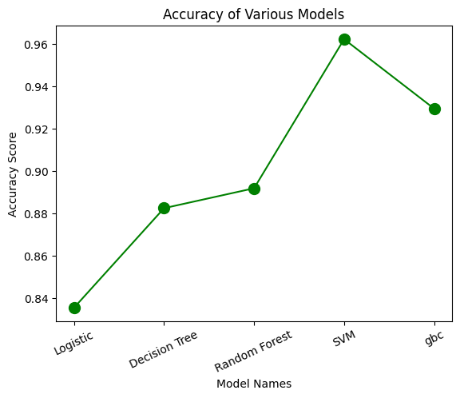

```python
plt.plot(range(1,6),
         [LR_accuracy,TREE_accuracy,FOREST_accuracy,SVM_accuracy,Gradient_Boosting_accuracy], marker='o',
        color = 'green', linestyle = '-', markersize = 10)
plt.xticks(range(1,6),['Logistic','Decision Tree','Random Forest','SVM','gbc'],
           rotation=25)
plt.title('Accuracy of Various Models')
plt.xlabel('Model Names')
plt.ylabel("Accuracy Score")
plt.show()
```